# Detecting Pneumonia with Deep Learning

In this notebook I tackle the computer vision task of detecting pneumonia from x-ray images of lungs using deep learning. The data consists of 5856 x-ray images taken from normally functioning lungs and lungs with pneumonia. The approach is to train a binary classifier that given an x-ray image, predicts either 0 or 1 corresponding to whether the patient has pneumonia or not. The data is acquired from [Kaggle](https://www.kaggle.com/paultimothymooney/chest-xray-pneumonia).

First, let's load the libraries used:

```python
 # For model building
import tensorflow.keras as K
from tensorflow.keras import models
from tensorflow.keras import layers
from tensorflow.keras.preprocessing.image import ImageDataGenerator # For data augmentation
# For data processing and model testing
from sklearn.utils import shuffle
from sklearn.model_selection import train_test_split
from sklearn import metrics
import numpy as np # For data processing
import pandas as pd # For data processing and visualization

# For data visualization
import matplotlib.pyplot as plt
import seaborn as sns
import cv2 # For image processing
import os # For data inputting
```

## Data Input

I define a function for reading the data from local memory. The data is pre-divded into training, validation and testing sets. The directory structure for the data is as follows:

```
root_dir/
│
└───train/
│   │
│   └───Normal/
│   │
│   │       imagename1.jpg
│   │       imagename2.jpg
│   │       ...
│   │
│   └───Pneumonia/
│           imagename1.jpg
│           imagename2.jpg
│           ...
└───test/
│   │
│   └───Normal/
│   │
│   │       imagename1.jpg
│   │       imagename2.jpg
│   │       ...
│   │
│   └───Pneumonia/
│           imagename1.jpg
│           imagename2.jpg
│           ...
└───val/
    │
    └───Normal/
    │
    │       imagename1.jpg
    │       imagename2.jpg
    │       ...
    │
    └───Pneumonia/
            imagename1.jpg
            imagename2.jpg
            ...
```

The function reads the images from all directories into the preffered size using the cv2 library. It returns a tuple containing the images and labels (0 for normal, 1 for pneumonia) stored as numpy arrays for each data subset. The function also preprocesses the images by rescaling the color channel values from 0:255 to 0:1.

```python
IMG_SIZE = 256
def read_data(root_dir, img_size = IMG_SIZE):
    train_x = []
    train_y = []
    test_x = []
    test_y = []
    val_x = []
    val_y = []
    for dataset in ["test", "train", "val"]:
        for labelint, label in enumerate(["Normal", "Pneumonia"]):
            dirpath = os.path.join(root_dir, dataset, label)
            for img in os.listdir(dirpath):
                curimg = cv2.imread(os.path.join(dirpath, img), cv2.IMREAD_GRAYSCALE)
                curimg = cv2.resize(curimg, (img_size, img_size))
                curimg = curimg/255
                if(dataset == "test"):
                    test_x.append(curimg)
                    test_y.append(labelint)
                elif(dataset == "train"):
                    train_x.append(curimg)
                    train_y.append(labelint)
                else:
                    val_x.append(curimg)
                    val_y.append(labelint)
    train_x = np.array(train_x).reshape(-1, img_size, img_size, 1)
    train_y = np.array(train_y)
    test_x = np.array(test_x).reshape(-1, img_size, img_size, 1)
    test_y = np.array(test_y)
    val_x = np.array(val_x).reshape(-1, img_size, img_size, 1)
    val_y = np.array(val_y)
    return((train_x, train_y, test_x, test_y, val_x, val_y))
```

A single example stored in a numpy array is of shape (img_size, img_size, 1)

```python
train_x, train_y, test_x, test_y, val_x, val_y = read_data("chest_xray")
train_x[0].shape
```

```
(256, 256, 1)
```

Some example images from the training data set printed with their labels. It is difficult for the untrained human eye to see the differences in the pneumonia-infested lungs to those with no infection. Hopefully deep learning can do a bit better.

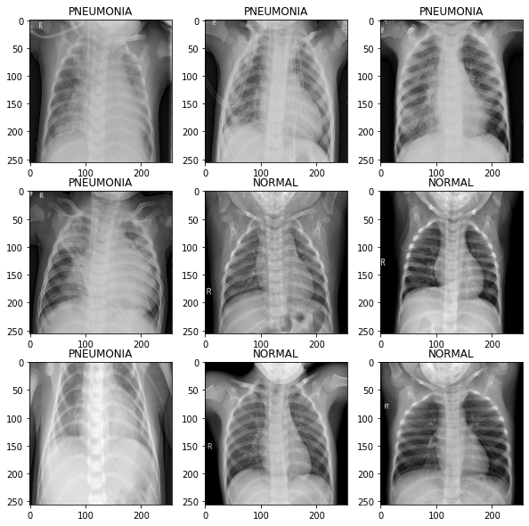

```python
train_x, train_y = shuffle(train_x, train_y)
labeldict = {0: "NORMAL", 1:"PNEUMONIA"}
fig, axs = plt.subplots(3,3)
fig.set_size_inches(10,10)
for i in range(3):
    for j in range(3):
        axs[i][j].imshow(train_x[3*i+j], cmap = "gray")
        axs[i][j].set_title(labeldict[train_y[3*i + j]])
```

## Preprocessing

By plotting the observations of the default data subsets, we can notice that the division is quite imbalanced. For one, there are only 16 examples in the validation set and also the proportion of the classes of images are quite uneven.

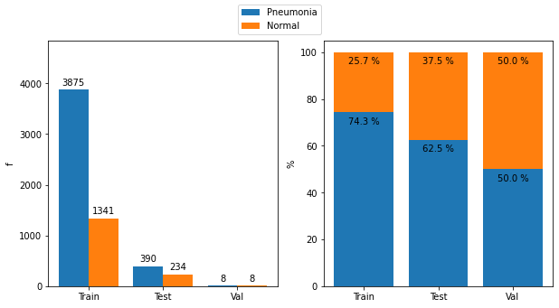

```python
def countBarPlot(train_y, val_y, test_y):
    train_counts = np.unique(train_y, return_counts = True)[1]
    test_counts = np.unique(test_y, return_counts = True)[1]
    val_counts = np.unique(val_y, return_counts = True)[1]
    normal_counts = [x[0] for x in (train_counts, test_counts, val_counts)]
    pneum_counts = [x[1] for x in (train_counts, test_counts, val_counts)]
    x = np.arange(3)
    width = 0.4
    fig, axs = plt.subplots(1,2)
    rect1 = axs[0].bar(x-width/2, pneum_counts, width = width, label = "Pneumonia")
    rect2 = axs[0].bar(x+width/2, normal_counts, width = width, label = "Normal")

    def autolabel(rects, ax, xoffset = 0, yoffset = 3, formatstr = "{height:.0f}"):
        for rect in rects:
            height = rect.get_height()
            ax.annotate(formatstr.format(height = height),
                        xy=(rect.get_x() + rect.get_width() / 2, height + rect.get_y()),
                        xytext=(xoffset, yoffset),
                        textcoords="offset points",
                        ha='center', va='bottom')
    autolabel(rect1, axs[0])
    autolabel(rect2, axs[0])
    axs[0].set_ylim([0, max(max((pneum_counts, normal_counts))) * 1.25])
    axs[0].set_xticks(x)
    axs[0].set_xticklabels(["Train", "Test", "Val"])
    axs[0].set_ylabel("f")
    train_p = train_counts/len(train_y) * 100
    test_p = test_counts/len(test_y) * 100
    val_p = val_counts/len(val_y) * 100

    normal_p = [x[0] for x in (train_p, test_p, val_p)]
    pneum_p = [x[1] for x in (train_p, test_p, val_p)]

    rects3 = axs[1].bar(x, pneum_p, label = "Pneumonia", width = 2*width)
    rects4 = axs[1].bar(x, normal_p, bottom = pneum_p, label = "Normal", width = 2*width)
    axs[1].set_xticks(x)
    axs[1].set_xticklabels(["Train", "Test", "Val"])
    axs[1].set_ylabel("%")

    autolabel(rects3, axs[1], 0, -15, "{height:.1f} %")
    autolabel(rects4, axs[1], 0, -15, "{height:.1f} %")
    handles, labels = axs[1].get_legend_handles_labels()
    fig.legend(handles, labels, loc='upper center')
    fig.set_size_inches(10,5)
countBarPlot(train_y, val_y, test_y)
```

I redefine the train-val-test split for the dataset using a 0.8 - 0.1 - 0.1 split. This results in having 4684 training examples and 586 validation and testing examples. We also obtain a much more balanced class distribution between the sets.

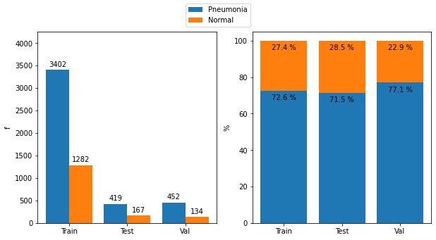

```python
all_x = np.concatenate((train_x, test_x, val_x))
all_y = np.concatenate((train_y, test_y, val_y))
train_x, test_and_val_x, train_y, test_and_val_y = train_test_split(all_x, all_y, test_size = 0.2)
val_x, test_x, val_y, test_y = train_test_split(test_and_val_x, test_and_val_y, test_size = 0.5)
del all_x
del all_y
countBarPlot(train_y, val_y, test_y)
```

## Data Augmentation

I use data augmentation to prevent overfitting and maximize generalization. The training set images are randomly flipped, zoomed, panned, sheared and rotated to create a more versatile training set. The data augmentation is implemented with a generator at training time, and thus the model has a really small probability to process exactly the same training example twice. Some augmented training examples are printed below with their labels.

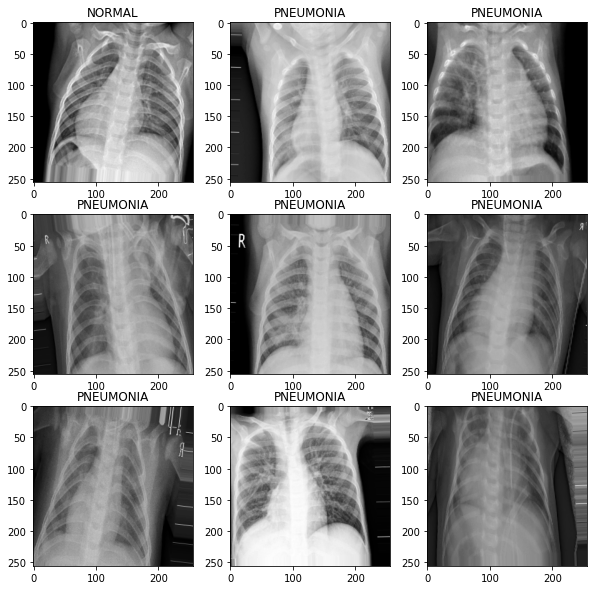

```python
data_augm = ImageDataGenerator(horizontal_flip = True, zoom_range = 0.1, rotation_range = 10,
        width_shift_range=0.1,
        height_shift_range=0.1, shear_range = 0.1)
fig, axs = plt.subplots(3,3)
fig.set_size_inches(10,10)
for i, (X, Y) in enumerate(data_augm.flow(train_x, train_y)):
    axs[int(i/3)][i % 3].imshow(X[0], cmap = "gray")
    axs[int(i/3)][i % 3].set_title(labeldict[Y[0]])
    if i == 8:
        break
```

## Model Building

The goal is to build and train feasable sized neural network that detects pneumonia from the images. The problem boils down to a binary image recognition task, where the neural network gets an image as an input and outputs a real number between 0 and 1 corresponding to the confidence the model has of the input image belonging to class "Pneumonia". The neural network attempts to find the parameters that minimize the binary crossentropy cost defined as: \begin{equation} \sum_{i=1}^n y_i\log{p_i} + (1-y_i)\log(1-p_i) \end{equation} for the $n$ predictions $p$ and true class labels $y$ (0 for normal, 1 for pneumonia).

### Linear Classifier

I use a linear classifier, namely logistic regression to define a baseline for model performance. The linear classifier has 65537 parameters, one for each pixel value and one bias term. It calculates the prediction \begin{equation} p = \textrm{sigmoid}(\sum_{i=1}^{65536} (w_ix_i) + b) \end{equation} where $x_i$ are the pixel values. The adaptive moments estimation algorithm with learning rate 1e-5 is used for optimization. Early stopping of training is used for the validation loss to prevent overfitting and excessively long training. The classification accuracy is also monitored.

```python
linear_classifier = models.Sequential()

linear_classifier.add(layers.Flatten())
linear_classifier.add(layers.Dense(1, activation = K.activations.sigmoid))
linear_classifier.compile(loss="binary_crossentropy", optimizer = K.optimizers.Adam(learning_rate=1e-5), metrics=['acc'])
linear_classifier.build(train_x.shape)
```

```python
linear_classifier.summary()
```

```
Model: "sequential"
_________________________________________________________________
Layer (type)                 Output Shape              Param #
=================================================================
flatten (Flatten)            (4684, 65536)             0
_________________________________________________________________
dense (Dense)                (4684, 1)                 65537
=================================================================
Total params: 65,537
Trainable params: 65,537
Non-trainable params: 0
_________________________________________________________________
```

```python
es = K.callbacks.EarlyStopping(
    monitor="val_loss",
    min_delta=0.001,
    patience=10,
    verbose=1,
    mode="auto",
    baseline=None,
    restore_best_weights=True,
)
linear_fit = linear_classifier.fit(data_augm.flow(train_x, train_y), steps_per_epoch = train_x.shape[0]/128, validation_data=(val_x, val_y), epochs=100, batch_size = 128, callbacks = [es])
```

```
Epoch 00077: early stopping
```

The linear classifier achieves about 0.24 mean binary crossentropy and about 91.8 % classification accuracy for the validation set which is a good baseline for the deep learning model to improve upon. The metrics for the training data and the learning curves are also displayed below.

```
Training metrics: {'loss': 0.2806193232536316, 'acc': 0.8958155512809753}
Validation metrics: {'loss': 0.24160631000995636, 'acc': 0.9180887341499329}
```

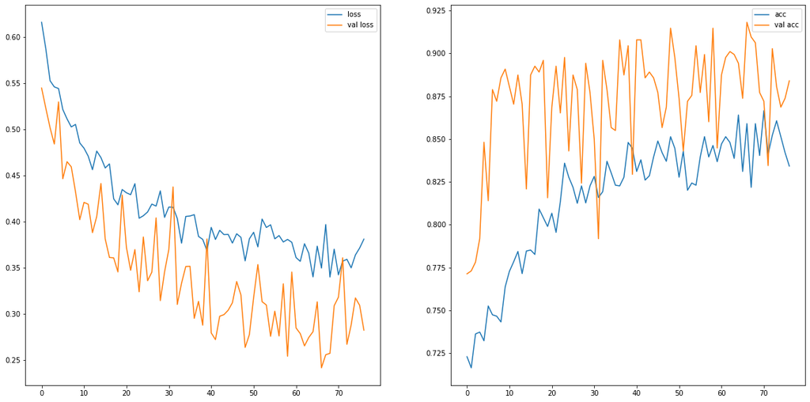

```python
print("Training metrics:", linear_classifier.evaluate(train_x, train_y, verbose = 0, return_dict = True))
print("Validation metrics:", linear_classifier.evaluate(val_x, val_y, verbose = 0, return_dict = True))
fig, (ax1, ax2) = plt.subplots(1,2)
ax1.plot(linear_fit.history["loss"], label = "loss")
ax1.plot(linear_fit.history["val_loss"], label = "val loss")
ax1.legend()
ax2.plot(linear_fit.history["acc"], label = "acc")
ax2.plot(linear_fit.history["val_acc"], label = "val acc")
ax2.legend()
fig.set_size_inches(20,10)
```

### Convolutional Network

Next, I build the convolutional neural network architecture. It uses four convolutional layers with max-pooling followed by a densely connected layer with 32 nodes. The last layer uses the sigmoid activation function where as the others use ReLU. In total, the model has 535 257 parameters. The optimization algorithm is the same as with the linear classifier with a bit larger learning rate. The model is trained for 150 epochs, with a batch size of 128. I again use early stopping on validation loss select the best model.

```python
cnn = models.Sequential()

cnn.add(layers.Conv2D(filters = 8, kernel_size = 2, strides = 1, padding = "same"))
cnn.add(layers.ReLU())
cnn.add(layers.MaxPooling2D((2,2), 2, "valid"))
cnn.add(layers.Conv2D(filters = 16, kernel_size = 2, strides = 1, padding = "same"))
cnn.add(layers.MaxPooling2D((2,2), 2, "valid"))
cnn.add(layers.ReLU())
cnn.add(layers.Conv2D(filters = 32, kernel_size = 2, strides = 1, padding = "same"))
cnn.add(layers.ReLU())
cnn.add(layers.MaxPooling2D((2,2), 2, "valid"))
cnn.add(layers.Conv2D(filters = 64, kernel_size = 2, strides = 1, padding = "same"))
cnn.add(layers.ReLU())
cnn.add(layers.MaxPooling2D((2,2), 2, "valid"))
cnn.add(layers.Flatten())
cnn.add(layers.Dense(32))
cnn.add(layers.ReLU())
cnn.add(layers.Dense(1, activation = K.activations.sigmoid))

cnn.compile(loss = "binary_crossentropy", optimizer = K.optimizers.Adam(1e-4), metrics=['acc'])
cnn.build(train_x.shape)
```

```python
cnn.summary()
```

```
Model: "sequential_1"
_________________________________________________________________
Layer (type)                 Output Shape              Param #
=================================================================
conv2d (Conv2D)              (4684, 256, 256, 8)       40
_________________________________________________________________
re_lu (ReLU)                 (4684, 256, 256, 8)       0
_________________________________________________________________
max_pooling2d (MaxPooling2D) (4684, 128, 128, 8)       0
_________________________________________________________________
conv2d_1 (Conv2D)            (4684, 128, 128, 16)      528
_________________________________________________________________
max_pooling2d_1 (MaxPooling2 (4684, 64, 64, 16)        0
_________________________________________________________________
re_lu_1 (ReLU)               (4684, 64, 64, 16)        0
_________________________________________________________________
conv2d_2 (Conv2D)            (4684, 64, 64, 32)        2080
_________________________________________________________________
re_lu_2 (ReLU)               (4684, 64, 64, 32)        0
_________________________________________________________________
max_pooling2d_2 (MaxPooling2 (4684, 32, 32, 32)        0
_________________________________________________________________
conv2d_3 (Conv2D)            (4684, 32, 32, 64)        8256
_________________________________________________________________
re_lu_3 (ReLU)               (4684, 32, 32, 64)        0
_________________________________________________________________
max_pooling2d_3 (MaxPooling2 (4684, 16, 16, 64)        0
_________________________________________________________________
flatten_1 (Flatten)          (4684, 16384)             0
_________________________________________________________________
dense_1 (Dense)              (4684, 32)                524320
_________________________________________________________________
re_lu_4 (ReLU)               (4684, 32)                0
_________________________________________________________________
dense_2 (Dense)              (4684, 1)                 33
=================================================================
Total params: 535,257
Trainable params: 535,257
Non-trainable params: 0
_________________________________________________________________
```

```python
cnn_fit = cnn.fit(data_augm.flow(train_x, train_y), steps_per_epoch = train_x.shape[0]/128, validation_data=(val_x, val_y), epochs=150, batch_size = 128, callbacks = [es])
```

```
Epoch 00069: early stopping
```

The convolutional model achieves about 0.13 mean binary crossentropy and 95.39 % classification accuracy on the validation set, which is a significant improvement over the linear classifier.

```
Training metrics: {'loss': 0.1720476746559143, 'acc': 0.9393680691719055}
Validation metrics: {'loss': 0.13411113619804382, 'acc': 0.9539248943328857}
```

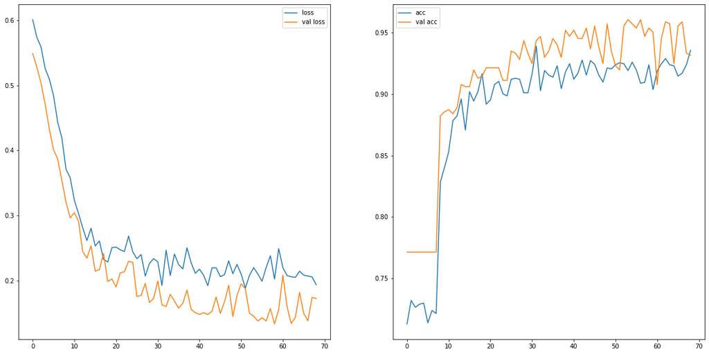

```python
print("Training metrics:", cnn.evaluate(train_x, train_y, verbose = 0, return_dict = True))
print("Validation metrics:", cnn.evaluate(val_x, val_y, verbose = 0, return_dict = True))
fig, (ax1, ax2) = plt.subplots(1,2)
ax1.plot(cnn_fit.history["loss"], label = "loss")
ax1.plot(cnn_fit.history["val_loss"], label = "val loss")
ax1.legend()
ax2.plot(cnn_fit.history["acc"], label = "acc")
ax2.plot(cnn_fit.history["val_acc"], label = "val acc")
ax2.legend()
fig.set_size_inches(20,10)
```

## Validation

Here are the predicted probabilities for the misclassified test cases at cutoff 0.5. We can see that although there are quite many gross misclassifications, there are also a few "close calls". Adjusting the cutoff value might change the results.

```python
preds = cnn.predict(val_x).reshape(-1,)
incorrect = val_y != (preds > 0.5)
pd.DataFrame({"True Label" : val_y[incorrect], "Predicted Value" : preds[incorrect]})
```

|  | True Label | Predicted Value |
| --- | --- | --- |
| 0 | 0 | 0.549011 |
| 1 | 1 | 0.013203 |
| 2 | 1 | 0.428040 |
| 3 | 1 | 0.203713 |
| 4 | 1 | 0.468417 |
| 5 | 1 | 0.490398 |
| 6 | 1 | 0.373902 |
| 7 | 0 | 0.567865 |
| 8 | 0 | 0.908293 |
| 9 | 0 | 0.923704 |
| 10 | 0 | 0.602038 |
| 11 | 0 | 0.988324 |
| 12 | 1 | 0.185041 |
| 13 | 1 | 0.410080 |
| 14 | 1 | 0.361179 |
| 15 | 0 | 0.530018 |
| 16 | 0 | 0.615878 |
| 17 | 0 | 0.921214 |
| 18 | 1 | 0.297671 |
| 19 | 0 | 0.748776 |
| 20 | 1 | 0.135839 |
| 21 | 0 | 0.683852 |
| 22 | 0 | 0.519925 |
| 23 | 0 | 0.547146 |
| 24 | 1 | 0.066999 |
| 25 | 1 | 0.263688 |
| 26 | 0 | 0.834622 |

In a clinical setup we often want a test to have a high recall (or true positive rate), even if it leads to a lower specificity (false positive rate). It is more dangerous for a clinical test to miss an actual infection than to generate some false alarms. Precision (rate of true positives in all positives) is also an important measure and often the goal is to find a good balance of precision and recall. Precision can be translated into "the probability that the subject has pneumonia given that the model detected pneumonia". The harmonic mean of precision and recall is often used to aggregate the two measures, and is also known as the $F_1$ score.

\begin{equation} F_1 = \frac{2}{\frac{1}{\textrm{precision}} + \frac{1}{\textrm{recall}}} \end{equation}

A way of visualizing sensitivity and specificity at different cut of values is by plotting the receiver operating characteristic curve. The area under the ROC curve is a good indication for model performance, especially when the predicted classes are well balanced in the test set. It ranges from 0 to 1 where a naive classifier gets a score of 0.5. The ROC curve for the linear classifier is also plotted for reference.

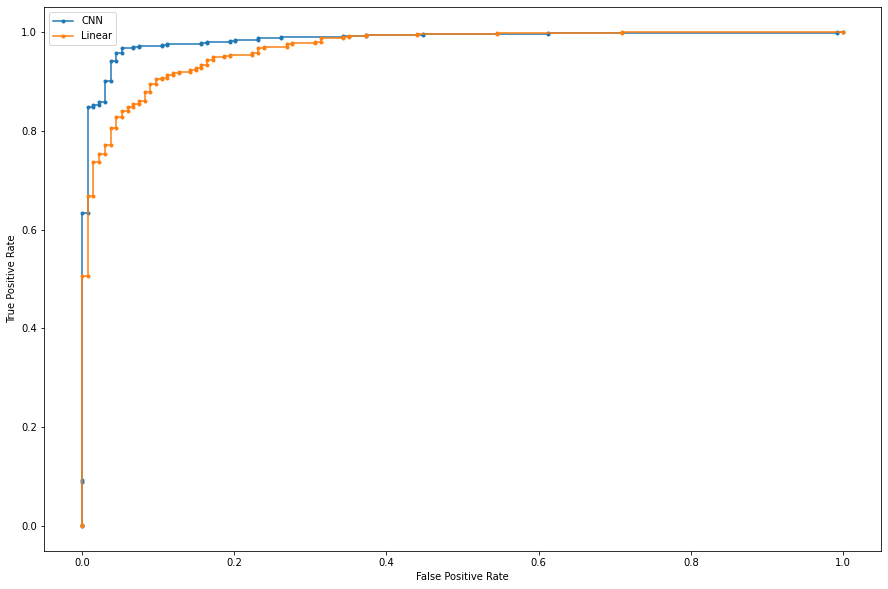

```
Area Under ROC curve:
Linear 0.967
CNN 0.985
```

```python
preds = cnn.predict(val_x)
preds_linear = linear_classifier.predict(val_x)
fpr, tpr, _ = metrics.roc_curve(val_y, preds)
fprl, tprl, _ = metrics.roc_curve(val_y, preds_linear)
plt.plot(fpr, tpr, marker = ".", label = "CNN")
plt.plot(fprl, tprl, marker = ".", label = "Linear")
plt.xlabel("False Positive Rate")
plt.ylabel("True Positive Rate")
plt.legend()
plt.gcf().set_size_inches(15,10)
plt.show()
print("Area Under ROC curve:")
print("Linear", "{0:.3f}".format(metrics.roc_auc_score(val_y, preds_linear)))
print("CNN", "{0:.3f}".format(metrics.roc_auc_score(val_y, preds)))
```

Next, I plot the $F_1$ scores, precisions and recall scores to find the optimum value of cutoff in the validation set.

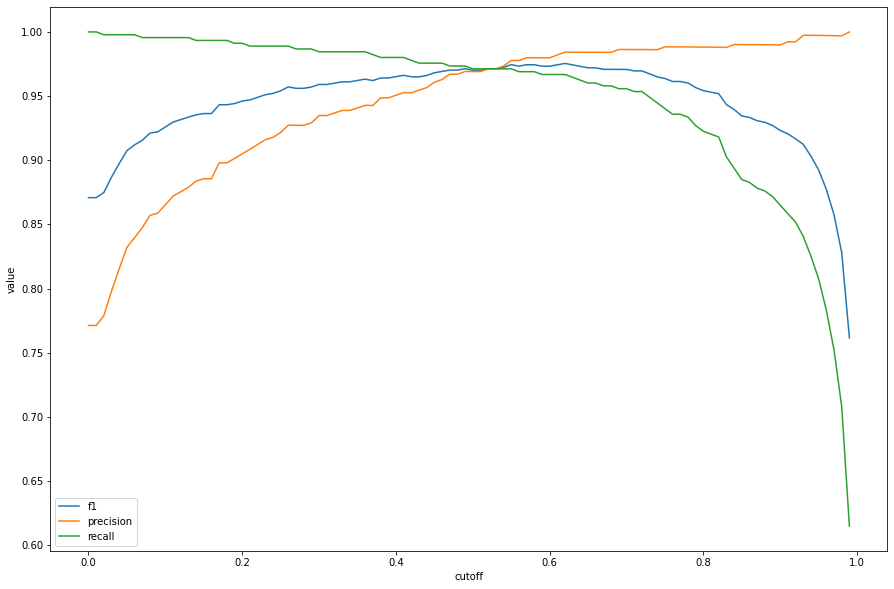

```python
f1_scores = []
precisions = []
recalls = []
cutoffs = np.arange(0, 1, 0.01)
for cutoff in cutoffs:
    f1 = metrics.f1_score(val_y, preds > cutoff)
    f1_scores.append(f1)
    precision = metrics.precision_score(val_y, preds > cutoff)
    recall = metrics.recall_score(val_y, preds > cutoff)
    precisions.append(precision)
    recalls.append(recall)
f1_scores = np.array(f1_scores)
precisions = np.array(precisions)
recalls = np.array(recalls)
plt.plot(cutoffs, f1_scores, label = "f1")
plt.plot(cutoffs, precisions, label = "precision")
plt.plot(cutoffs, recalls, label = "recall")
plt.legend()
plt.ylabel("value")
plt.xlabel("cutoff")
plt.gcf().set_size_inches(15,10)
```

We can now select the best cutoff value for any optimality criterion. One such criterion could be the maximum $F_1$ score achieved. In this medical context a better criterion could be to those a cutoff value that achieves some predetermined level of recall, such as 0.99. Then we would have a model which detects 0.99 percent of pneumonia cases and generates the minimun amount of false positives.

```python
RECALL_BOUND = 0.985
print("Highest F1 score:", "{0:.3f}".format(np.max(f1_scores)), "at cutoff:", "{0:.2f}".format(cutoffs[np.argmax(f1_scores)]))
print("Precision at recall", str(RECALL_BOUND) + ":", "{0:.3f}".format(np.max(precisions[recalls > RECALL_BOUND])), "at cutoff:",  "{0:.2f}".format(cutoffs[recalls > RECALL_BOUND][np.argmax(precisions[recalls > RECALL_BOUND])]))
```

```
Highest F1 score: 0.975 at cutoff: 0.62
Precision at recall 0.985: 0.929 at cutoff: 0.29
```

Here are the confusion matrices displaying the predicted labels against the true labels at the two cutoff values obtained above.

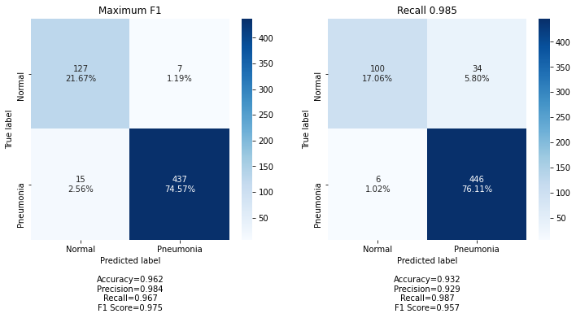

```python
from cm import make_confusion_matrix
fig, axs = plt.subplots(1,2)
make_confusion_matrix(metrics.confusion_matrix(val_y, preds > cutoffs[np.argmax(f1_scores)]), ax = axs[0], title = "Maximum F1", categories = ["Normal", "Pneumonia"])
make_confusion_matrix(metrics.confusion_matrix(val_y, preds > cutoffs[recalls > RECALL_BOUND][np.argmax(precisions[recalls > RECALL_BOUND])]), ax = axs[1], title = "Recall " + str(RECALL_BOUND), categories = ["Normal", "Pneumonia"])
fig.set_size_inches(12,5)
plt.show()
```

## Testing

The convolutional model with the chosen cutoff values will be evaluated on the test set to receive an unbiased estimate of model performance on new data. The confusion matrices with the chosen cutoff values are displayed below.

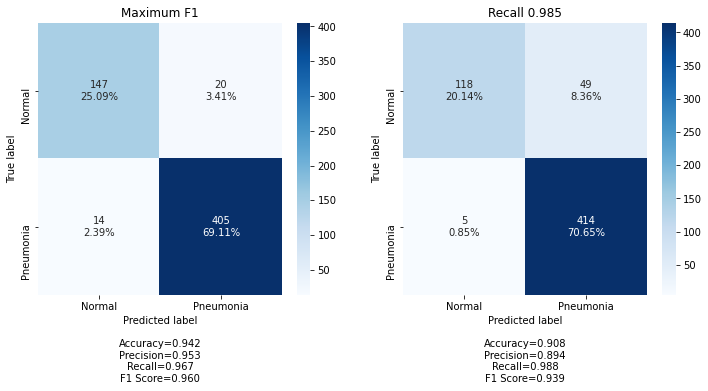

```python
test_preds = cnn.predict(test_x)
fig, axs = plt.subplots(1,2)
make_confusion_matrix(metrics.confusion_matrix(test_y, test_preds > cutoffs[np.argmax(f1_scores)]), ax = axs[0], title = "Maximum F1", categories = ["Normal", "Pneumonia"])
make_confusion_matrix(metrics.confusion_matrix(test_y, test_preds > cutoffs[recalls > RECALL_BOUND][np.argmax(precisions[recalls > RECALL_BOUND])]), ax = axs[1], title = "Recall " + str(RECALL_BOUND), categories = ["Normal", "Pneumonia"])
fig.set_size_inches(12,5)
plt.show()
```

Here are some example predictions for the latter cutoff

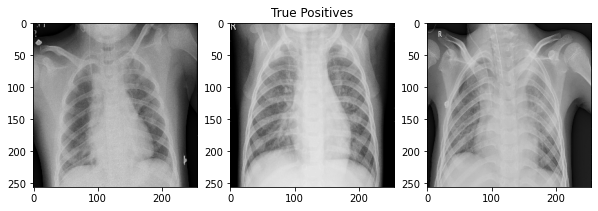

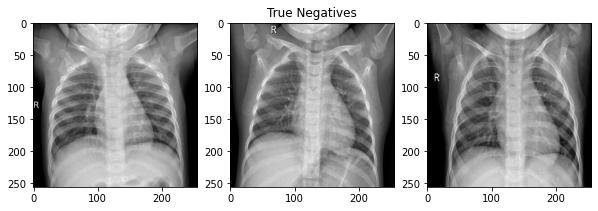

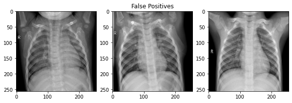

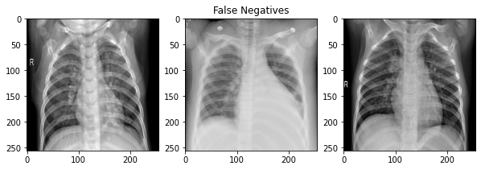

```python
preds_classes = np.array(test_preds > cutoffs[recalls > RECALL_BOUND][np.argmax(precisions[recalls > RECALL_BOUND])])
true_positives =  np.logical_and(np.equal(preds_classes.reshape(-1,), test_y), np.equal(np.array((1,)), test_y))
true_negatives =  np.logical_and(np.equal(preds_classes.reshape(-1,), test_y), np.equal(np.array((0,)), test_y))
false_positives = np.logical_and(np.invert(np.equal(preds_classes.reshape(-1,), test_y)), np.equal(np.array((0,)), test_y))
false_negatives = np.logical_and(np.invert(np.equal(preds_classes.reshape(-1,), test_y)), np.equal(np.array((1,)), test_y))

fig, axs = plt.subplots(1,3)
fig.set_size_inches(10,10)
for i in range(3):
    axs[i].imshow(test_x[true_positives][i], cmap = "gray")
axs[1].set_title("True Positives")

fig, axs = plt.subplots(1,3)
fig.set_size_inches(10,10)
for i in range(3):
    axs[i].imshow(test_x[true_negatives][i], cmap = "gray")
axs[1].set_title("True Negatives")
fig, axs = plt.subplots(1,3)
fig.set_size_inches(10,10)
for i in range(3):
    axs[i].imshow(test_x[false_positives][i], cmap = "gray")
axs[1].set_title("False Positives")
fig, axs = plt.subplots(1,3)
fig.set_size_inches(10,10)
for i in range(3):
    axs[i].imshow(test_x[false_negatives][i], cmap = "gray")
axs[1].set_title("False Negatives")
plt.show()
```